# Find best hotels with machine learning

DA3 Assignment 3

Viktória Mészáros

14/02/2021

## Introduction

The aim of this analysis is to find the best deals for hotels in Vienna. This is built on the “Finding a Good Deal among Hotels with Multiple Regressions” case study in the 10th chapter. For this I will use different machine learning models to predict the price of the hotels based on the different features they have. After this I will search for the places where the actual price is the lowest compare to the predicted (calculating most negative residuals). I will outline the 5 best hotels based on the best models and compare them to the findings of the original case study.

## Data preparation

We start the analysis with the hotelbookingdata which contains data about 23 thousand different hotels in 33 unique countries collected between 2017 November and 2018 June. As we are only interested in the hotels in Vienna we filter down our data set to this city. In Vienna there were 516 observations, but a lot of them were in the table multiple times due to different points in time. I wanted one observation for each hotel, so for this I filter the data set down to only a given year and month to get comparable values. I chose 2017 November weekdays, the same what we used in the case study as I wanted to get an output that is comparable. After dropping duplicated rows my data set decreased to 428 observations.

## Explanatory data analysis

### Filtering

I started explanatory data analysis with looking at different possible values as well as extremes. I wanted to find the best deal among hotels so I had to filter out other accommodation types. After checking actual city I realized that some hotels are not actually located in Vienna. I deleted those. I only kept observations that had 3, 3.5 or 4 stars and that were at maximum 8 miles away from the city center. I also excluded hotels that had extreme prices. With all these I had a final 207 hotels from which I wanted to find the best deal.

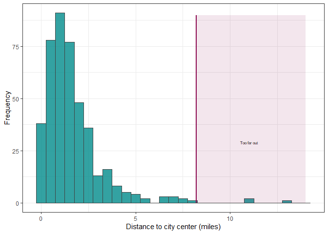

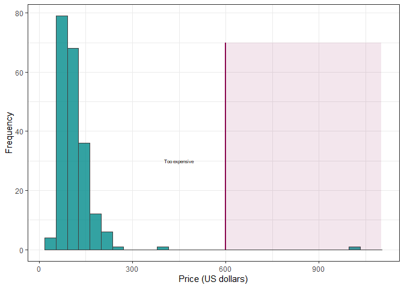

### Missing values

I only had missing values for TripAdvisors rating and thus rating count fro 3 hotels. I decided to use imputation in these cases. I substituted 4 as the TripAdvisor rating for these observations as that was the rounded mean and median for all the others. For TripAdvisors rating count I imputed the mean of all other rating counts. I also added flags for the imputed variables.

### Potential functional forms

The outcome variable in the analysis will be **Price**. Let’s look at the distribution of prices. We can see that it is skewed with a long right tail. In these cases it is advised to do a logarithmic transformation. On the second graph you can see that taking the log of price transforms its distribution to closer to normal. Based on this we are going to predict **lnprice** instead of price.

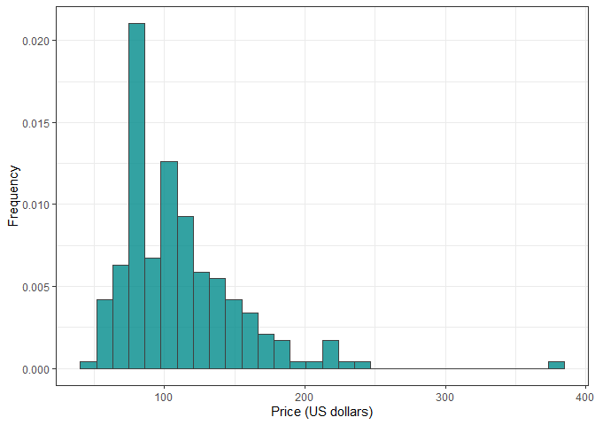

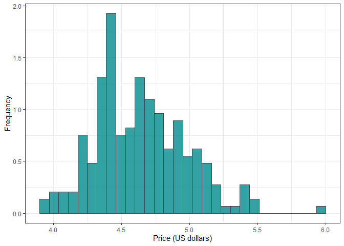

For distance from the city center and rating I included piecewise linear spline as the pattern is not even close to simple linear, but it is different for different intervals. For this I searched for the best cuts with an algorithm. FBased on this, for distance there will be three knots at 1.1, 2.9 and 4.3 while for rating there will be two at 3.2 and 3.8.

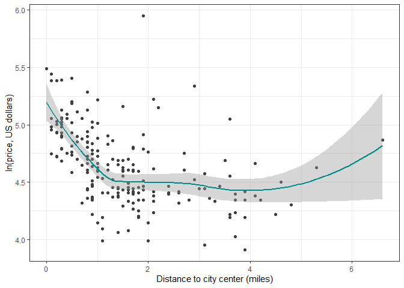

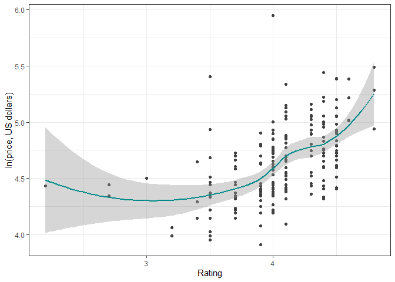

## Modelling

### Set up

The aim of the analysis was to find the best deals among hotels. For this I built 4 different types of models to predict prices and then find the most underpriced hotels. The outcome variable for all the models will be **lnprice**. Fot the feature variables I grouped them into three separate categories:

- **basic variables** – *lspline(distance) + lspline(rating) + stars*
- **ratings variables** – *rating count + TripAdvisor rating + TripAdvisor rating count + flags for missing values*
- **extra variables** – *scarce romm dummy + offer dummy + offer category + neighborhood*

I built three simple ols models with different levels of complexity, one LASSO model containing all variable, one CART model and two random forest models one with manual tuning grid and one with auto tuning. For these instead of the piecewise linear spline in distance and in rating I used simply the distance and the rating. The following table helps to understand what features are included in what models. I used a 10 fold cross validation during training all the models.

|  | Variables |
| --- | --- |
| OLS 1 | basic |
| OLS 2 | basic + ratings |
| OLS 3 | basic + ratings + extra |
| LASSO | basic + ratings + extra |
| CART | distance + rating + starts + ratings + extra |
| Random forest | distance + rating + starts + ratings + extra |

### Comparison

|  | CV RMSE | CV R squared |
| --- | --- | --- |
| Simple reg | 0.2241 | 0.5683 |
| OLS 1 | 0.2266 | 0.5615 |
| OLS 2 | 0.2293 | 0.5575 |
| OLS 3 | 0.2295 | 0.5628 |
| LASSO | 0.2130 | 0.6243 |
| CART | 0.2629 | 0.4208 |
| Random forest | 0.2236 | 0.5761 |
| Random forest auto | 0.2300 | 0.5401 |

## Best deals

I decided to look at the 5 best deals which has the smallest residual values both for the LASSO an the random forest models. With predicting the log of price when looking at the most negative residuals to find the best deals we are looking at highest percentage difference. Here we are not looking at the best hotels where that has the highest USD difference between the actual price and the predicted but the percentage difference (for example here it is better deal when the actual price is 50 compared to a predicted price of 55, than when the actual is 200 compared to 215). The table below shows the best five deals for the simple regression in the book, the LASSO , the cart and the random forest models I built. Let’s compare the best 5 hotels I got wit different models and what we found during the initial case study. It is interesting to see that there are several hotels that came out to be the best deal for more models.

- The best hotel based on the book’s regression, lasso and the random forest is 21912, and it is also in the top 5 for the cart
- 22344 is second for both lasso and random forest models, and third for the cart
- 22080 is in the best five for lasso as well
- 22184 is also listed for cart and random forest
- 21975 is not considered a best deal for other models

| Reg in book | reg_resid | Lasso | laso_resid | Cart | cart_resid | Random Forest | rf_resid |
| --- | --- | --- | --- | --- | --- | --- | --- |
| 21912 | -0.5646 | 21912 | -0.5337 | 22165 | -0.5124 | 21912 | -0.3215 |
| 21975 | -0.4051 | 22344 | -0.4235 | 22354 | -0.5061 | 22344 | -0.2690 |
| 22344 | -0.3846 | 22075 | -0.3482 | 22344 | -0.4163 | 22205 | -0.2492 |
| 22080 | -0.3384 | 22080 | -0.3246 | 21912 | -0.4100 | 22184 | -0.2049 |
| 22184 | -0.3349 | 22205 | -0.3063 | 22184 | -0.4036 | 21984 | -0.1999 |

### Visuals

These visuals give a nice representation of the best deals. These are the dots that are furthest down from the 45°line. These are really similar to what we saw for the regression in the book, except for the cart model. There we see only some predicted prices, those are the values for the final nodes in the tree. You can see the whole tree in the appendix.

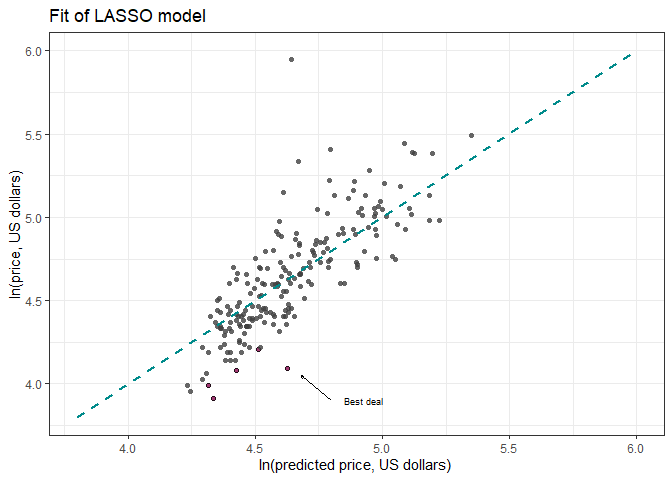

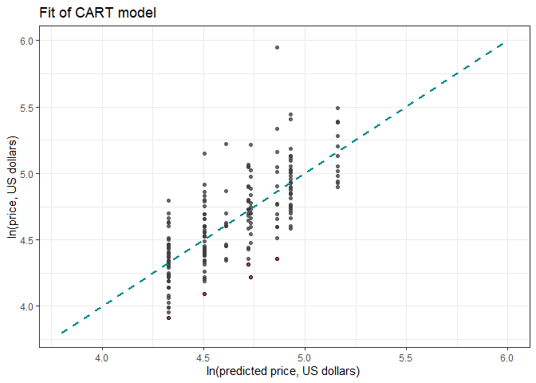

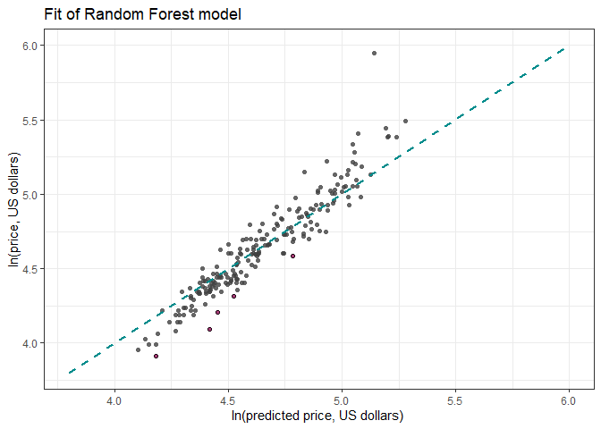

## Appendix

### How price is depending on the different features

The following charts were part of the explanatory data analysis. Here I looked at how price depends on each variable.

#### Number of stars

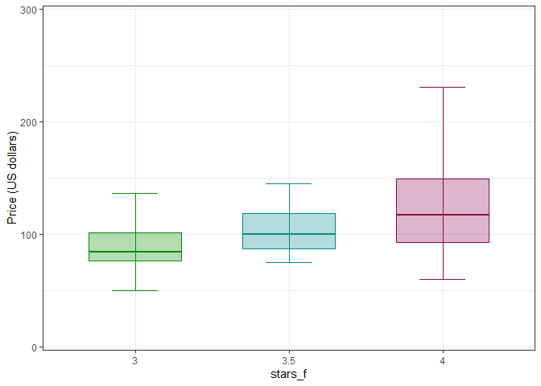

#### TipAdvisor rating

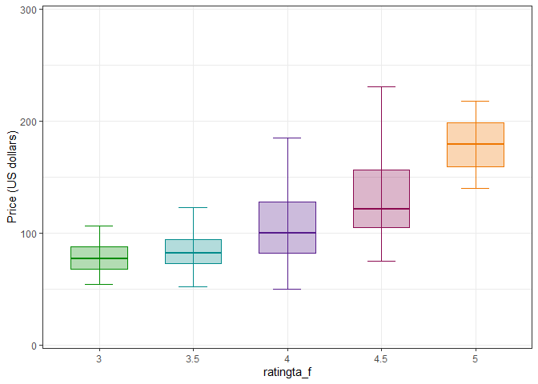

#### Scarce room

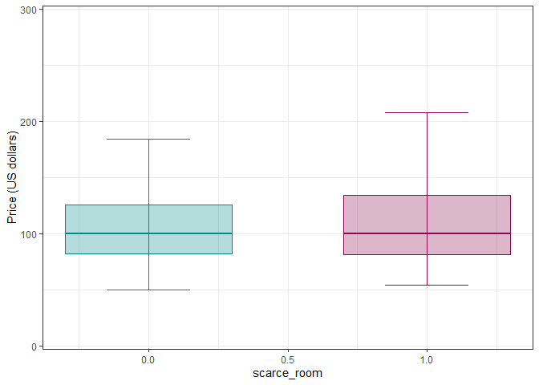

#### Offer

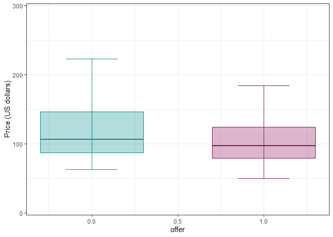

#### Offer category

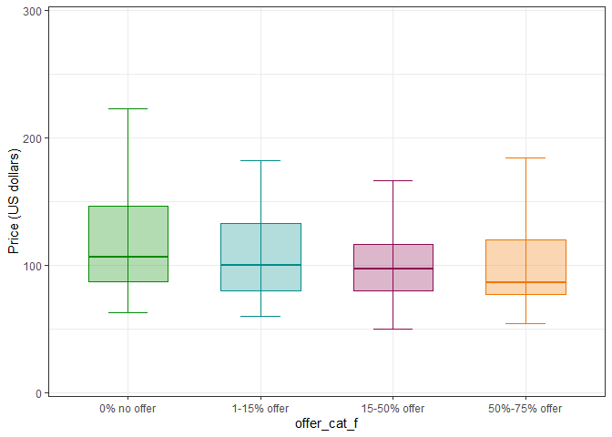

#### Neighborhood

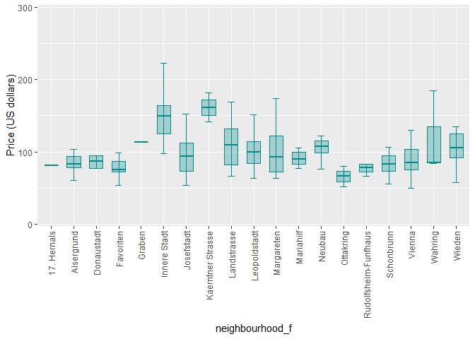

### CART model graph

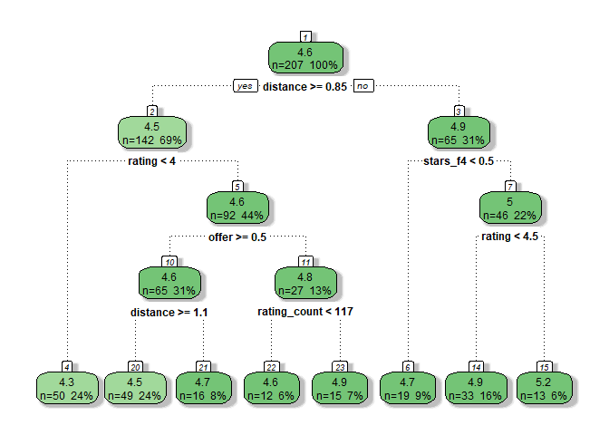